# Project-parameter estimation method

Zhiwei Li

2020/5/6

# 参数估计方法

## 极大似然估计法

极大似然法，也称最大似然法，最早由德国数学家高斯于1821年提出，在1912，英国统计学家罗纳德费歇尔再次提出了此方法的思想，并证明了该方法的一些性质。

极大似然法是不同于普通最小二乘法的另一种参数估计方法，它是从极大似然原理出发发展起来的其他参数估计方法的基础。普通最小二乘法是当从模型总体中随机抽取n组样本观测值后，最合理的参数估计量应该使得此模型能最好地拟合样本数据；而对于极大似然法，是当从模型总体中随机抽取 n 组样本观测值后，最合理的参数估计量应该使得从此模型中抽取该n组样本观测值的概率最大。因此，极大似然原理比最小二乘原理更本质地揭示了通过样本估计总体参数的内在机理，在参数估计中占据着重要的地位。 这里通过线性回归模型实例来介绍极大似然估计的思想。对于一元线性回归模型$Y=\beta_0 + \beta_1X + \mu$，随机抽取n组样本观测值${{(X_i,Y_i):i=1,2,...,n}}$,由于$Y_i$服从如下正态分布：
$$Y_i\sim N(\beta_0 + \beta_1X_i, \delta^2)$$
于是，$Y_i$的概率函数为
$$P(Y_i)=\frac{1}{\delta \sqrt{2\pi}}exp\{-\frac{1}{2\delta^2}(Y_i-\beta_0 - \beta_1X_i)^2\}, i=1,2,\cdots,n$$
因为$\{Y_i,i=1,2,\cdots,n\}$是相互独立的，所以Y的所有样本观测值得联合概率密度，即似然函数为：
$$L(\beta_0,\beta_1,\delta^2)=P(Y_1,Y_2,\cdots,Y_n)=\frac{1}{(2\pi)^{\frac{n}{2}}\delta^2}exp\{{-\frac{1}{2\delta^2}}\Sigma(Y_i-\beta_0-\beta_1X_i)^2\}$$
将该似然函数最大化，即可求出模型参数的极大似然估计量。 由于似然函数的极大化与似然函数对数的极大化是等价的，所以对数似然函数如下：
$$L^*=lnL=-nln(\sqrt{2\pi}\delta )-\frac{1}{2\delta^2}\Sigma(Y_i-\beta_o-\beta_1X_i)^2$$
对$L^*$求极大值，等价于对$\Sigma(Y_i-\beta_o-\beta_1X_i)^2$求极小值。设$\hat{\beta_0}$,$\hat{\beta_1}$满足该极值条件，即
$$\frac{\partial}{\partial\hat{\beta_0}}\Sigma(Y_i-\beta_o-\beta_1X_i)^2=0$$
$$\frac{\partial}{\partial\hat{\beta_1}}\Sigma(Y_i-\beta_o-\beta_1X_i)^2=0$$
解得模型的参数估计量为：
$$\hat{\beta_0}=\frac{\Sigma X_i^2 \Sigma Y_i - \Sigma X_i \Sigma Y_iX_i}{n\Sigma X_i^2-(\Sigma X_i)^2}$$
$$\hat{\beta_1}=\frac{n\Sigma Y_iX_i - \Sigma Y_i \Sigma X_i}{n\Sigma X_i^2-(\Sigma X_i)^2}$$

## 基于SEIR模型的疫情分析-极大似然函数法

对于SEIR模型，我们根据新冠疫情的发展，做出以下假设：

(1)假设易感者为总人口规模的10%，即$N=1.4\times10^8$，初始只有一个感染者，没有潜伏者，也没有移出者，即初始状态空间为$C_0=(S_0,E_0,I_0,R_0)=(N-1,0,1,0)$;

(2)根据其他学者研究，设定平均潜伏期为4.98天，即$\frac{1}{\delta}=4.98$,平均感染期为7.04天，即$\frac{1}{\gamma}=7.04$;

(3)假定控制措施在1月23日开始实施。

(4)假设病人的累计人数服从泊松分布。

同时，假定在控制措施实施之前，传染率是恒定不变的常数$\beta$，在控制措施实施之后，传染率呈指数下降，即传染率$\beta(t)=\beta e^{[-k(t-\tau)]}$，其中$k$为一个控制系数。

在给定初始状态的情况下，结合SEIR模型、极大似然估计法和Nelder-Mead最优算法，对待估参数进行估计。 对于极大似然估计法，我们通过病例的累计人数C服从泊松分布来建立似然函数：
$$L=\Sigma \frac{\hat{C}^c}{C!}e^{-\hat{C}}$$
其中$\hat{C}$表示病例累计人数的模拟序列，C表示病例累计人数的原始序列。

### 参数估计结果

根据SEIR微分方程模型，采用极大似然估计法，并结合 Nelder-Mead 最优算法，得出新冠肺炎在全国范围内爆发的传染率$\beta$为0.618,并由此得出基本再生数$R_0$,基本再生数$R_0$表示在干预之前，完全易感人群中一个病例在整个传染期内平均感染的人数，即$R_0 = \beta/\gamma$,经计算，国内疫情的基本再生数$R_0$为4.35。由此可以看出，在国家实施控制措施之前，新冠肺炎会继续蔓延而形成疫情的大流行，此时只有政府实施控制措施使其降至1以下时，新冠肺炎才会得到有效控制，并最终慢慢消失。

### 有效再生数分析

对于控制系数$k$来说，在全国疫情发展下，控制系数$k$为0.0723。$k>0$说明政府的控制措施能够有效的抑制新冠肺炎的传播。为了更好的体现控制措施干预后埃博拉病毒的传播过程是否得到抑制，可以通过有效再生数指标来进一步体现，根据有效再生数的定义计算得出有效再生数$R(t)$为$4.35e^{(-0.0723t)}$，可以看出其呈指数下降，下降到1的日期在2020年2月12日，如图1所示。这表明在SEIR模型下，政府的控制干预措施对新冠疫情发展的抑制作用是有效的。

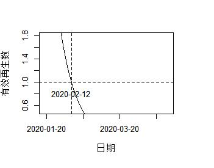

### 拟合曲线分析

通过对上述参数的估计及分析，利用参数的估计值，结合SEIR模型模拟出新冠肺炎病例的累计人数的拟合值，并做出相应的曲线与真实观测值进行对比，如图2所示。我们发现疫情真实发展的观测值与拟合值得发展趋势基本一致，拟合曲线基本吻合，这表明SEIR模型对全国疫情的传播机制和传播速度都能够给出有效的解释和说明。

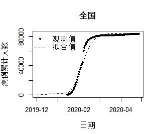

## 模拟退火算法

SEIR模型由微分方程组构成，若已知疫情传播的初始状态，并给定模型参数集$P=(\beta,\delta,\gamma)\in R^3$,便可利用四阶龙格-库塔方法解析得到相对的疫情传播过程，及各个时刻t的$S(t),E(t),I(t),R(t)$,现在已知每天新增的病例数，而反应疫情传播特征的参数未知。因此可以利用模拟退火算法对参数进行优化求解。模拟退火算法的目标函数$loss$设置如下：
$$loss=\frac{\sqrt{\sum_{i=1}^{N}(obs_i - est_i)^2}}{(\sqrt{\sum_{i=1}^{N}obs_i^2}+\sqrt{\sum_{i=1}^{N}est_i^2})}$$
其中，$obs_i$为实际的每天新增的病例数，$est_i$为模拟得到的每日新增病例数。 模拟退火算法模型参数的优化过程如图3：

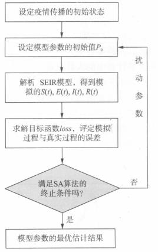

### 模拟退火算法的原理

在目标函数给定之后，如果想要求函数的全局最优解，如图4所示，如果采用Greedy策略，那么从A点开始试探，如果函数值继续减少，那么试探过程就会继续。而当到达点B时，显然我们的探求过程就结束了（因为无论朝哪个方向努力，结果只会越来越大）。最终我们只能找打一个局部最后解B。

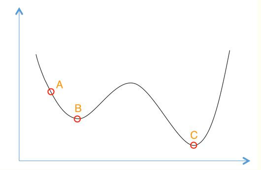

模拟退火其实也是一种Greedy算法，但是它的搜索过程引入了随机因素。模拟退火算法以一定的概率来接受一个比当前解要差的解，因此有可能会跳出这个局部的最优解，达到全局的最优解。以上图为例，模拟退火算法在搜索到局部最优解B后，会以一定的概率接受向右继续移动。也许经过几次这样的不是局部最优的移动后会到达B 和C之间的峰点，于是就跳出了局部最小值B。

根据Metropolis准则，粒子在温度T时趋于平衡的概率为exp(-ΔE/(kT))，其中E为温度T时的内能，ΔE为其改变数,k为Boltzmann常数。Metropolis准则常表示为

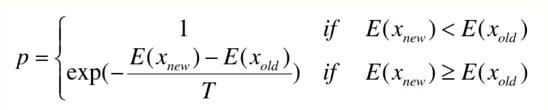

Metropolis准则表明，在温度为T时，出现能量差为dE的降温的概率为P(dE)，表示为：P(dE) = exp( dE/(kT) )。其中k是一个常数，exp表示自然指数，且dE<0。所以P和T正相关。这条公式就表示：温度越高，出现一次能量差为dE的降温的概率就越大；温度越低，则出现降温的概率就越小。又由于dE总是小于0（因为退火的过程是温度逐渐下降的过程），因此dE/kT < 0 ，所以P(dE)的函数取值范围是(0,1) 。随着温度T的降低，P(dE)会逐渐降低。

我们将一次向较差解的移动看做一次温度跳变过程，我们以概率P(dE)来接受这样的移动。也就是说，在用固体退火模拟组合优化问题，将内能E模拟为目标函数值 f，温度T演化成控制参数t，即得到解组合优化问题的模拟退火演算法：由初始解 i 和控制参数初值 t 开始，对当前解重复“产生新解→计算目标函数差→接受或丢弃”的迭代，并逐步衰减 t 值，算法终止时的当前解即为所得近似最优解，这是基于蒙特卡罗迭代求解法的一种启发式随机搜索过程。退火过程由冷却进度表(Cooling Schedule)控制，包括控制参数的初值 t 及其衰减因子Δt 、每个 t 值时的迭代次数L和停止条件S。

总结起来就是：

(1)若f( Y(i+1) ) <= f( Y(i) )(即移动后得到更优解)，则总是接受该移动；

(2)若f( Y(i+1) ) > f( Y(i) )(即移动后的解比当前解要差)，则以一定的概率接受移动，而且这个概率随着时间推移逐渐降低（逐渐降低才能趋向稳定）相当于上图中，从B移向BC之间的小波峰时，每次右移（即接受一个更糟糕值）的概率在逐渐降低。如果这个坡特别长，那么很有可能最终我们并不会翻过这个坡。如果它不太长，这很有可能会翻过它，这取决于衰减 t 值的设定。